# CE_690_Jha_Shreepati_Term_Project - Study on Risky Intersection Behaviour

Shreepati Jha

2025-04-23

For this study, we’ll be using the IPT_Data_Hyderabad1.csv dataset which is a dataset on a survey of auto/taxi drivers to recored their demographic information, understanding their prefernces realted to mobile payments, aggrigators and their behaviour in the traffic scenariors.

## Reading the CSV file and loading onto a dataframe called hydipt

```r
hydipt <- read.csv("C:/Users/shree/Downloads/IPT_Data_Hyderabad1.csv", header = TRUE)
names(hydipt)
```

```
##  [1] "SN"                        "Age"
##  [3] "Vehicle_Type"              "Ola_Uber_Issues"
##  [5] "Work_Hours"                "Job_Concern"
##  [7] "Enough_Passengers"         "Traffic_Impact"
##  [9] "Mobile_Payments"           "Mobile_Concerns"
## [11] "Income_Range"              "Household_Size"
## [13] "Income_Structure"          "Vehicle_Insurance"
## [15] "Preferred_Vehicle"         "Rent_vs_Own"
## [17] "Own_Vehicle"               "Vehicle_Purchase"
## [19] "Driving_Frequency"         "Driving_Distance"
## [21] "Change_Speed_Intersection" "Red_Light_Response"
## [23] "Intersection_Factors"      "Front_Vehicle_Stop"
## [25] "Front_Vehicle_Motion"      "Check_Speedometer"
## [27] "Speed_Straight"            "Speed_LeftTurn"
## [29] "Speed_RightTurn"           "Lane_RightTurn"
## [31] "Lane_LeftTurn"             "Lane_Straight"
## [33] "Yellow_Signal_Meaning"     "GreenToYellow_Confusion"
## [35] "Caught_RedLight_Yellow"    "Running_RedLight_Yellow"
## [37] "Amber_SufficientTime"      "RoadSigns_Notice"
## [39] "Sign_SpeedLimit"           "Sign_NoEntry"
## [41] "Sign_CrossRoad"            "Sign_NoUTurn"
## [43] "Sign_GiveWay"              "Sign_X"
```

Inference - The data has 44 Variables

## Performing basic EDA on the ipt dataset to understand the dataset

```r
head(hydipt)
```

```
##   SN   Age  Vehicle_Type                    Ola_Uber_Issues Work_Hours
## 1  1 30-45 3-seater Auto                           Not Used         <8
## 2  2   <30 3-seater Auto                           Not Used     10-Aug
## 3  3 30-45 3-seater Auto Not getting enoughpassenger/income     10-Aug
## 4  4   <30           Van                           Not Used     12-Oct
## 5  5   <30           Van                           Not Used     12-Oct
## 6  6 45-60    E-rickshaw                           Not Used         <8
##                  Job_Concern                 Enough_Passengers
## 1            No safe parking No due to competition from others
## 2 Competition for passengers                  No due to CORONA
## 3  Traffic Jam and Pollution                               Yes
## 4                No concerns                               Yes
## 5                No concerns                               Yes
## 6  Traffic Jam and Pollution                               Yes
##          Traffic_Impact  Mobile_Payments  Mobile_Concerns Income_Range
```

[output cut: 76 more lines]

```r
str(hydipt)
```

```
## 'data.frame':    276 obs. of  44 variables:
##  $ SN                       : int  1 2 3 4 5 6 7 8 9 10 ...
##  $ Age                      : chr  "30-45" "<30" "30-45" "<30" ...
##  $ Vehicle_Type             : chr  "3-seater Auto" "3-seater Auto" "3-seater Auto" "Van" ...
##  $ Ola_Uber_Issues          : chr  "Not Used" "Not Used" "Not getting enoughpassenger/income" "Not Used" ...
##  $ Work_Hours               : chr  "<8" "10-Aug" "10-Aug" "12-Oct" ...
##  $ Job_Concern              : chr  "No safe parking" "Competition for passengers" "Traffic Jam and Pollution" "No concerns" ...
##  $ Enough_Passengers        : chr  "No due to competition from others" "No due to CORONA" "Yes" "Yes" ...
##  $ Traffic_Impact           : chr  "Lost income" "Stress/Anxiety" "Lost income" "Pollution" ...
##  $ Mobile_Payments          : chr  "I already accept" "yes" "No" "yes" ...
##  $ Mobile_Concerns          : chr  "No concerns" "No concerns" "Delay in payment" "No concerns" ...
##  $ Income_Range             : chr  "10000-15000" "<10000" "10000-15000" "10000-15000" ...
##  $ Household_Size           : int  3 4 5 5 5 4 6 7 4 5 ...
##  $ Income_Structure         : chr  "Fixed  salary" "Fixed  salary" "Based on no. of passengers" "Based on no. of passengers" ...
##  $ Vehicle_Insurance        : chr  "None" "None" "Life insurance only" "Health and life insurance" ...
```

[output cut: 30 more lines]

```r
summary(hydipt)
```

```
##        SN             Age            Vehicle_Type       Ola_Uber_Issues
##  Min.   :  1.00   Length:276         Length:276         Length:276
##  1st Qu.: 69.75   Class :character   Class :character   Class :character
##  Median :138.50   Mode  :character   Mode  :character   Mode  :character
##  Mean   :138.50
##  3rd Qu.:207.25
##  Max.   :276.00
##
##   Work_Hours        Job_Concern        Enough_Passengers  Traffic_Impact
##  Length:276         Length:276         Length:276         Length:276
##  Class :character   Class :character   Class :character   Class :character
##  Mode  :character   Mode  :character   Mode  :character   Mode  :character
##
##
##
##
##  Mobile_Payments    Mobile_Concerns    Income_Range       Household_Size
##  Length:276         Length:276         Length:276         Min.   :2.000
##  Class :character   Class :character   Class :character   1st Qu.:4.000
##  Mode  :character   Mode  :character   Mode  :character   Median :5.000
##                                                           Mean   :4.685
##                                                           3rd Qu.:5.000
##                                                           Max.   :8.000
##
##  Income_Structure   Vehicle_Insurance  Preferred_Vehicle  Rent_vs_Own
##  Length:276         Length:276         Length:276         Length:276
##  Class :character   Class :character   Class :character   Class :character
##  Mode  :character   Mode  :character   Mode  :character   Mode  :character
##
##
##
##
##  Own_Vehicle        Vehicle_Purchase   Driving_Frequency Driving_Distance
##  Length:276         Length:276         Min.   :1.000     Min.   :  18.0
##  Class :character   Class :character   1st Qu.:1.000     1st Qu.: 103.8
##  Mode  :character   Mode  :character   Median :1.000     Median : 150.0
##                                        Mean   :1.446     Mean   : 222.9
##                                        3rd Qu.:2.000     3rd Qu.: 242.5
##                                        Max.   :3.000     Max.   :3000.0
##
```

[output cut: 41 more lines]

```
##  Min.   :0.000    Min.   :0.0000   Min.   :0.0000   Min.   :0.0000
##  1st Qu.:1.000    1st Qu.:1.0000   1st Qu.:0.0000   1st Qu.:0.0000
##  Median :2.000    Median :1.0000   Median :1.0000   Median :0.0000
##  Mean   :1.818    Mean   :0.7754   Mean   :0.6022   Mean   :0.4074
##  3rd Qu.:2.000    3rd Qu.:1.0000   3rd Qu.:1.0000   3rd Qu.:1.0000
##  Max.   :4.000    Max.   :1.0000   Max.   :1.0000   Max.   :1.0000
##  NA's   :2                         NA's   :7        NA's   :33
##   Sign_NoUTurn     Sign_GiveWay        Sign_X
##  Min.   :0.0000   Min.   :0.0000   Min.   :1
##  1st Qu.:1.0000   1st Qu.:0.0000   1st Qu.:1
##  Median :1.0000   Median :0.0000   Median :1
##  Mean   :0.9216   Mean   :0.3767   Mean   :1
##  3rd Qu.:1.0000   3rd Qu.:1.0000   3rd Qu.:1
##  Max.   :1.0000   Max.   :1.0000   Max.   :1
##  NA's   :21       NA's   :61       NA's   :224
```

Based on the review of the data set and its variables, it can be concluded that the dataset has a vast categories of variables which covers socio-economic, perception, behavioral dataset in a traffic situation for the auto/taxi drivers in the city of Hyderabad. In order to narrow down the scope of work of the study, only the traffic aspect will be focoused upon in this study.

A potential reserch problem could be Predicting Risky Intersection Behavior Driven by Misinterpretation of Traffic Signals.

Can drivers’ misinterpretation of yellow signals, combined with driving speed patterns and cognitive factors, predict the likelihood of running red lights during the yellow-to-red transition?

Looking at the variables, a few relvent variables to the proposed reserch questions were shortlisted and EDA was performed on them. The variables are RedLight_Binary,Change_Speed_Intersection,Speed_Straight,Speed_LeftTurn,Speed_RightTurn,Yellow_Signal_Meaning,GreenToYellow_Confusion,Amber_SufficientTime,Sign_SpeedLimit,Sign_NoEntry.

In the EDA, for each of the variables, the categories were revised, adjusted and leveled accordingly.

# EDA for chosen Varables

## Age

```r
library(dplyr)
hydipt %>%
  count(Age) %>%
  mutate(Rel_Freq = n / sum(n))
```

```
##     Age   n  Rel_Freq
## 1 30-45 169 0.6123188
## 2 45-60  28 0.1014493
## 3   <30  38 0.1376812
## 4   >60  41 0.1485507
```

```r
library(forcats)


hydipt$Age <- recode(hydipt$Age,
                     "<30" = "Under 30",
                     "30-45" = "30-45",
                     "45-60" = "45-60",
                     ">60"  = "More than 60")

hydipt$Age <- factor(hydipt$Age, levels = c("Under 30", "30-45", "45-60", "More than 60"))
hydipt %>% count(Age)
```

```
##            Age   n
## 1     Under 30  38
## 2        30-45 169
## 3        45-60  28
## 4 More than 60  41
```

## Work hours

```r
hydipt %>%
  count(Work_Hours) %>%
  mutate(Rel_Freq = n / sum(n))
```

```
##   Work_Hours   n   Rel_Freq
## 1     10-Aug 186 0.67391304
## 2     12-Oct  53 0.19202899
## 3         <8  25 0.09057971
## 4        >12  12 0.04347826
```

```r
hydipt %>%
  count(Work_Hours) %>%
  mutate(Work_Hours = recode(Work_Hours,
                             "10-Aug" = "8-10",
                             "12-Oct" = "10-12")) %>%
  mutate(Rel_Freq = n / sum(n))
```

```
##   Work_Hours   n   Rel_Freq
## 1       8-10 186 0.67391304
## 2      10-12  53 0.19202899
## 3         <8  25 0.09057971
## 4        >12  12 0.04347826
```

```r
hydipt$Work_Hours <- recode(hydipt$Work_Hours,
                            "<8" = "Up to 8",
                            "10-Aug" = "8-10",
                            "12-Oct" = "10-12",
                            ">12" = "More than 12")

hydipt$Work_Hours <- factor(hydipt$Work_Hours, levels = c("Up to 8", "8-10", "10-12", "More than 12"))

hydipt %>% count(Work_Hours)
```

```
##     Work_Hours   n
## 1      Up to 8  25
## 2         8-10 186
## 3        10-12  53
## 4 More than 12  12
```

## Change_Speed_Intersection

```r
hydipt %>%
  count(Change_Speed_Intersection) %>%
  mutate(Rel_Freq = n / sum(n))
```

```
##   Change_Speed_Intersection   n   Rel_Freq
## 1                         0   6 0.02173913
## 2                         1 270 0.97826087
```

```r
hydipt$Change_Speed_Intersection <- recode(as.character(hydipt$Change_Speed_Intersection),
                                           "0" = "Yes",
                                           "1" = "No")

hydipt$Change_Speed_Intersection <- factor(hydipt$Change_Speed_Intersection,
                                           levels = c("Yes", "No"))
hydipt %>% count(Change_Speed_Intersection)
```

```
##   Change_Speed_Intersection   n
## 1                       Yes   6
## 2                        No 270
```

## Speed_Straight

```r
hydipt %>%
  count(Speed_Straight) %>%
  mutate(Rel_Freq = n / sum(n))
```

```
##   Speed_Straight   n    Rel_Freq
## 1              1   1 0.003623188
## 2              2  46 0.166666667
## 3              3 229 0.829710145
```

## Speed_LeftTurn

```r
hydipt %>%
  count(Speed_LeftTurn) %>%
  mutate(Rel_Freq = n / sum(n))
```

```
##   Speed_LeftTurn   n   Rel_Freq
## 1              1  25 0.09057971
## 2              2 220 0.79710145
## 3              3  31 0.11231884
```

## Speed_RightTurn

```r
hydipt %>%
  count(Speed_RightTurn) %>%
  mutate(Rel_Freq = n / sum(n))
```

```
##   Speed_RightTurn   n   Rel_Freq
## 1               1  24 0.08695652
## 2               2 223 0.80797101
## 3               3  29 0.10507246
```

## Yellow_Signal_Meaning

```r
hydipt %>%
  count(Yellow_Signal_Meaning) %>%
  mutate(Rel_Freq = n / sum(n))
```

```
##           Yellow_Signal_Meaning   n  Rel_Freq
## 1                             0 114 0.4130435
## 2                             1  75 0.2717391
## 3 Slow and proceed with caution  87 0.3152174
```

```r
hydipt$Yellow_Signal_Meaning <- recode(as.character(hydipt$Yellow_Signal_Meaning),
                                       "0" = "Stop at the intersection",
                                       "1" = "Slow down and proceed with caution",
                                       "2" = "Continue through the intersection at the same speed",
                                       "3" = "Speed up to clear the intersection",
                                       "4" = "Horn and get out of the intersection")

hydipt$Yellow_Signal_Meaning <- factor(hydipt$Yellow_Signal_Meaning,
                                       levels = c("Stop at the intersection",
                                                  "Slow down and proceed with caution",
                                                  "Continue through the intersection at the same speed",
                                                  "Speed up to clear the intersection",
                                                  "Horn and get out of the intersection"))
hydipt %>% count(Yellow_Signal_Meaning)
```

```
##                Yellow_Signal_Meaning   n
## 1           Stop at the intersection 114
## 2 Slow down and proceed with caution  75
## 3                               <NA>  87
```

```r
hydipt <- hydipt %>%
  mutate(Yellow_Signal_Meaning = ifelse(is.na(Yellow_Signal_Meaning),
                                        "Horn and get out of the intersection",
                                        as.character(Yellow_Signal_Meaning))) %>%
  mutate(Yellow_Signal_Meaning = factor(Yellow_Signal_Meaning,
                                        levels = c("Stop at the intersection",
                                                   "Slow down and proceed with caution",
                                                   "Continue through the intersection at the same speed",
                                                   "Speed up to clear the intersection",
                                                   "Horn and get out of the intersection")))
hydipt %>% count(Yellow_Signal_Meaning)
```

```
##                  Yellow_Signal_Meaning   n
## 1             Stop at the intersection 114
## 2   Slow down and proceed with caution  75
## 3 Horn and get out of the intersection  87
```

## GreenToYellow_Confusion

```r
hydipt %>%
  count(GreenToYellow_Confusion) %>%
  mutate(Rel_Freq = n / sum(n))
```

```
##   GreenToYellow_Confusion   n   Rel_Freq
## 1                       0  27 0.09782609
## 2                       1 120 0.43478261
## 3                       2 108 0.39130435
## 4                       3  21 0.07608696
```

```r
hydipt$GreenToYellow_Confusion <- recode(as.character(hydipt$GreenToYellow_Confusion),
                                         "0" = "Quite confused",
                                         "1" = "Sometimes confused",
                                         "2" = "Hardly confused",
                                         "3" = "Do not remember")

hydipt$GreenToYellow_Confusion <- factor(hydipt$GreenToYellow_Confusion,
                                         levels = c("Quite confused", "Sometimes confused",
                                                    "Hardly confused", "Do not remember"))
hydipt %>% count(GreenToYellow_Confusion)
```

```
##   GreenToYellow_Confusion   n
## 1          Quite confused  27
## 2      Sometimes confused 120
## 3         Hardly confused 108
## 4         Do not remember  21
```

## Running_RedLight_Yellow

```r
hydipt %>%
  count(Running_RedLight_Yellow) %>%
  mutate(Rel_Freq = n / sum(n))
```

```
##   Running_RedLight_Yellow   n    Rel_Freq
## 1                       0   2 0.007246377
## 2                       1 118 0.427536232
## 3                       2 112 0.405797101
## 4                       3  44 0.159420290
```

```r
hydipt$Running_RedLight_Yellow <- recode(as.character(hydipt$Running_RedLight_Yellow),
                                         "0" = "Very often",
                                         "1" = "Sometimes",
                                         "2" = "Rarely",
                                         "3" = "Never")

hydipt$Running_RedLight_Yellow <- factor(hydipt$Running_RedLight_Yellow,
                                         levels = c("Very often", "Sometimes", "Rarely","Never" ))
hydipt %>% count(Running_RedLight_Yellow)
```

```
##   Running_RedLight_Yellow   n
## 1              Very often   2
## 2               Sometimes 118
## 3                  Rarely 112
## 4                   Never  44
```

## Amber_SufficientTime

```r
hydipt %>%
  count(Amber_SufficientTime) %>%
  mutate(Rel_Freq = n / sum(n))
```

```
##   Amber_SufficientTime   n   Rel_Freq
## 1                    0 258 0.93478261
## 2                    1  18 0.06521739
```

```r
hydipt$Amber_SufficientTime <- recode(as.character(hydipt$Amber_SufficientTime),
                                      "0" = "Yes",
                                      "1" = "No")

hydipt$Amber_SufficientTime <- factor(hydipt$Amber_SufficientTime, levels = c("Yes", "No"))

hydipt %>% count(Amber_SufficientTime)
```

```
##   Amber_SufficientTime   n
## 1                  Yes 258
## 2                   No  18
```

## Sign_SpeedLimit

```r
hydipt %>%
  count(Sign_SpeedLimit) %>%
  mutate(Rel_Freq = n / sum(n))
```

```
##   Sign_SpeedLimit   n  Rel_Freq
## 1               0  62 0.2246377
## 2               1 214 0.7753623
```

```r
hydipt$Sign_SpeedLimit <- recode(as.character(hydipt$Sign_SpeedLimit),
                                 "0" = "No",
                                 "1" = "SPEED LIMIT")

hydipt$Sign_SpeedLimit <- factor(hydipt$Sign_SpeedLimit, levels = c("No", "SPEED LIMIT"))

hydipt$Sign_NoEntry <- recode(as.character(hydipt$Sign_NoEntry),
                              "0" = "No",
                              "1" = "NO ENTRY")

hydipt$Sign_NoEntry <- factor(hydipt$Sign_NoEntry, levels = c("No", "NO ENTRY"))
hydipt %>% count(Sign_SpeedLimit)
```

```
##   Sign_SpeedLimit   n
## 1              No  62
## 2     SPEED LIMIT 214
```

## Sign_NoEntry

```r
hydipt %>%
  count(Sign_NoEntry) %>%
  mutate(Rel_Freq = n / sum(n))
```

```
##   Sign_NoEntry   n   Rel_Freq
## 1           No 107 0.38768116
## 2     NO ENTRY 162 0.58695652
## 3         <NA>   7 0.02536232
```

```r
hydipt <- hydipt %>%
  mutate(Sign_NoEntry = ifelse(is.na(Sign_NoEntry), "No", as.character(Sign_NoEntry))) %>%
  mutate(Sign_NoEntry = factor(Sign_NoEntry, levels = c("No", "NO ENTRY")))
hydipt %>% count(Sign_NoEntry)
```

```
##   Sign_NoEntry   n
## 1           No 114
## 2     NO ENTRY 162
```

# Recoding Running_RedLight_Yellow into binary

As we propose in our hypothesis to understand the behavior of Running_RedLight_Yellow of the drivers, we’ll be recoding the variable Running_RedLight_Yellow in to a binary variable to perform the binary logit model.

```r
hydipt <- hydipt %>%
  mutate(RedLight_Binary = ifelse(Running_RedLight_Yellow %in% c("Sometimes", "Very often"), 1, 0))

# Check factor levels for Running_RedLight_Yellow
hydipt %>% count(RedLight_Binary)
```

```
##   RedLight_Binary   n
## 1               0 156
## 2               1 120
```

# Cross-Tabulations & Chi-Square Tests

```r
# Assuming your data frame is named df

# Speed vs Running Red Light at Yellow
table1 <- table(hydipt$Speed_Straight, hydipt$Running_RedLight_Yellow)
print(table1)
```

```
##
##     Very often Sometimes Rarely Never
##   1          0         0      0     1
##   2          0        18     19     9
##   3          2       100     93    34
```

```r
chisq.test(table1)
```

```
##
##  Pearson's Chi-squared test
##
## data:  table1
## X-squared = 6.419, df = 6, p-value = 0.3779
```

```r
#  Confusion at Yellow vs Speed Straight
table3 <- table(hydipt$GreenToYellow_Confusion, hydipt$Speed_Straight)
print(table3)
```

```
##
##                       1  2  3
##   Quite confused      0  6 21
##   Sometimes confused  1 23 96
##   Hardly confused     0 13 95
##   Do not remember     0  4 17
```

```r
chisq.test(table3)
```

```
##
##  Pearson's Chi-squared test
##
## data:  table3
## X-squared = 4.2604, df = 6, p-value = 0.6415
```

```r
#  Speed Limit Sign vs Red Light Binary
table4 <- table(hydipt$Sign_SpeedLimit, hydipt$RedLight_Binary)
print(table4)
```

```
##
##                 0   1
##   No           41  21
##   SPEED LIMIT 115  99
```

```r
chisq.test(table4)
```

```
##
##  Pearson's Chi-squared test with Yates' continuity correction
##
## data:  table4
## X-squared = 2.5203, df = 1, p-value = 0.1124
```

```r
#  Amber Time Sufficiency vs Running Red Light
table5 <- table(hydipt$Amber_SufficientTime, hydipt$Running_RedLight_Yellow)
print(table5)
```

```
##
##       Very often Sometimes Rarely Never
##   Yes          2       111    106    39
##   No           0         7      6     5
```

```r
chisq.test(table5)
```

```
##
##  Pearson's Chi-squared test
##
## data:  table5
## X-squared = 2.148, df = 3, p-value = 0.5423
```

```r
#  Age vs Speed Behavior (Straight)

table_age_speed <- table(hydipt$Age, hydipt$Speed_Straight)
print(table_age_speed)
```

```
##
##                  1   2   3
##   Under 30       0   4  34
##   30-45          0  27 142
##   45-60          0   8  20
##   More than 60   1   7  33
```

```r
chisq.test(table_age_speed)
```

```
##
##  Pearson's Chi-squared test
##
## data:  table_age_speed
## X-squared = 9.721, df = 6, p-value = 0.1369
```

```r
table_age_left <- table(hydipt$Age, hydipt$Speed_LeftTurn)
print(table_age_left)
```

```
##
##                  1   2   3
##   Under 30       2  29   7
##   30-45         11 140  18
##   45-60          6  20   2
##   More than 60   6  31   4
```

```r
chisq.test(table_age_left)
```

```
##
##  Pearson's Chi-squared test
##
## data:  table_age_left
## X-squared = 10.84, df = 6, p-value = 0.09344
```

```r
table_age_right <- table(hydipt$Age, hydipt$Speed_RightTurn)
print(table_age_right)
```

```
##
##                  1   2   3
##   Under 30       2  31   5
##   30-45          8 144  17
##   45-60          6  20   2
##   More than 60   8  28   5
```

```r
chisq.test(table_age_right)
```

```
##
##  Pearson's Chi-squared test
##
## data:  table_age_right
## X-squared = 16.509, df = 6, p-value = 0.01127
```

```r
#  Work Hours vs Running Red Light at Yellow

table_work_redlight <- table(hydipt$Work_Hours,  hydipt$Running_RedLight_Yellow)
print(table_work_redlight)
```

```
##
##                Very often Sometimes Rarely Never
##   Up to 8               1         6      9     9
##   8-10                  1        90     78    17
##   10-12                 0        17     22    14
##   More than 12          0         5      3     4
```

```r
chisq.test(table_work_redlight)
```

```
##
##  Pearson's Chi-squared test
##
## data:  table_work_redlight
## X-squared = 27.689, df = 9, p-value = 0.001075
```

```r
#  Green-to-Yellow Confusion vs Red Light Binary

table_confusion_redlight <- table(hydipt$GreenToYellow_Confusion, hydipt$RedLight_Binary)
print(table_confusion_redlight)
```

```
##
##                       0  1
##   Quite confused      6 21
##   Sometimes confused 67 53
##   Hardly confused    69 39
##   Do not remember    14  7
```

```r
chisq.test(table_confusion_redlight)
```

```
##
##  Pearson's Chi-squared test
##
## data:  table_confusion_redlight
## X-squared = 16.214, df = 3, p-value = 0.001025
```

# Binary logit for Risky intersection behaviour

## Inital model(Full model)

```r
model <- glm(RedLight_Binary ~ Age +Work_Hours+ Change_Speed_Intersection +
                                Speed_Straight +
                                Speed_LeftTurn +
                                Speed_RightTurn +
                                Yellow_Signal_Meaning +
                                GreenToYellow_Confusion +
                                Amber_SufficientTime +
                                Sign_SpeedLimit +
                                Sign_NoEntry,
             data = hydipt,
             family = binomial)
summary(model)
```

```
##
## Call:
## glm(formula = RedLight_Binary ~ Age + Work_Hours + Change_Speed_Intersection +
##     Speed_Straight + Speed_LeftTurn + Speed_RightTurn + Yellow_Signal_Meaning +
##     GreenToYellow_Confusion + Amber_SufficientTime + Sign_SpeedLimit +
##     Sign_NoEntry, family = binomial, data = hydipt)
##
## Coefficients:
##                                                            Estimate Std. Error
## (Intercept)                                                0.003312   1.633657
## Age30-45                                                   0.284851   0.508682
## Age45-60                                                  -0.039766   0.587215
## AgeMore than 60                                            0.233407   0.530429
## Work_Hours8-10                                             0.835873   0.533168
## Work_Hours10-12                                            0.270415   0.571781
## Work_HoursMore than 12                                     0.640494   0.796255
## Change_Speed_IntersectionNo                                0.149438   0.966778
## Speed_Straight                                             0.774710   0.403453
## Speed_LeftTurn                                            -0.763110   0.653086
## Speed_RightTurn                                           -0.146213   0.698225
## Yellow_Signal_MeaningSlow down and proceed with caution   -0.416935   0.337698
## Yellow_Signal_MeaningHorn and get out of the intersection -0.665306   0.321459
## GreenToYellow_ConfusionSometimes confused                 -1.380105   0.534582
## GreenToYellow_ConfusionHardly confused                    -1.736854   0.547414
## GreenToYellow_ConfusionDo not remember                    -1.758446   0.705603
## Amber_SufficientTimeNo                                     0.232070   0.581028
## Sign_SpeedLimitSPEED LIMIT                                 0.323507   0.342614
## Sign_NoEntryNO ENTRY                                      -0.274896   0.286389
##                                                           z value Pr(>|z|)
## (Intercept)                                                 0.002  0.99838
## Age30-45                                                    0.560  0.57549
## Age45-60                                                   -0.068  0.94601
## AgeMore than 60                                             0.440  0.65991
## Work_Hours8-10                                              1.568  0.11694
## Work_Hours10-12                                             0.473  0.63626
## Work_HoursMore than 12                                      0.804  0.42118
## Change_Speed_IntersectionNo                                 0.155  0.87716
## Speed_Straight                                              1.920  0.05483 .
## Speed_LeftTurn                                             -1.168  0.24262
## Speed_RightTurn                                            -0.209  0.83413
## Yellow_Signal_MeaningSlow down and proceed with caution    -1.235  0.21697
## Yellow_Signal_MeaningHorn and get out of the intersection  -2.070  0.03849 *
## GreenToYellow_ConfusionSometimes confused                  -2.582  0.00983 **
## GreenToYellow_ConfusionHardly confused                     -3.173  0.00151 **
## GreenToYellow_ConfusionDo not remember                     -2.492  0.01270 *
## Amber_SufficientTimeNo                                      0.399  0.68959
## Sign_SpeedLimitSPEED LIMIT                                  0.944  0.34505
## Sign_NoEntryNO ENTRY                                       -0.960  0.33712
## ---
## Signif. codes:  0 '***' 0.001 '**' 0.01 '*' 0.05 '.' 0.1 ' ' 1
##
## (Dispersion parameter for binomial family taken to be 1)
##
##     Null deviance: 377.91  on 275  degrees of freedom
## Residual deviance: 339.37  on 257  degrees of freedom
## AIC: 377.37
##
## Number of Fisher Scoring iterations: 4
```

The model was performed with the categorical variables, and to ensure that the levels are correctly interpreted by the model, the `library(forcats), factor` command was employed. Other than that, the dependent variable in the model was RedLight_Binary (new variable formed). Here in this model, we can see that multiple independent variables, such as *Age, Work_Hours, Change_Speed_Intersection,Speed_LeftTurn,Speed_RightTurn ,Yellow_Signal_Meaning(Slow down and proceed with caution) , Amber_SufficientTime,Sign_SpeedLimit, Sign_NoEntry* seems to be insignificant.Also, the intercept of the model is also not significant.

Next we go on to test for the Multicollinearity as we have a lot of categorical variables in our binomial model.We make use of the Variance Inflation Factor (VIF) to diagnose this.

### Check for multicollinearity

```r
library(car)
vif(model)
```

```
##                               GVIF Df GVIF^(1/(2*Df))
## Age                       2.170150  3        1.137841
## Work_Hours                1.957133  3        1.118416
## Change_Speed_Intersection 1.054273  1        1.026778
## Speed_Straight            1.331879  1        1.154071
## Speed_LeftTurn            4.497848  1        2.120813
## Speed_RightTurn           4.907752  1        2.215345
## Yellow_Signal_Meaning     1.207758  2        1.048323
## GreenToYellow_Confusion   1.251485  3        1.038096
## Amber_SufficientTime      1.268746  1        1.126386
## Sign_SpeedLimit           1.151332  1        1.073001
## Sign_NoEntry              1.171975  1        1.082578
```

The VIF reaveal two values, `GVIF` and `GVIF^(1/(2*Df))`, where the latter accounts for the adjusted generalized standard error inflation factor for the continuous predictors and categorical predictors. Using the latter value, we conclude that the model does not have multicollinearity, as VIF<4 for all the predictors.

With this information, we go on to revise our model, removing all the insignificant variables.

## Reduced model

```r
model1 <- glm(RedLight_Binary ~
                                Speed_Straight + Yellow_Signal_Meaning +

                                GreenToYellow_Confusion
                                ,
             data = hydipt,
             family = binomial)
summary(model1)
```

```
##
## Call:
## glm(formula = RedLight_Binary ~ Speed_Straight + Yellow_Signal_Meaning +
##     GreenToYellow_Confusion, family = binomial, data = hydipt)
##
## Coefficients:
##                                                           Estimate Std. Error
## (Intercept)                                                 0.4674     1.0483
## Speed_Straight                                              0.3913     0.3377
## Yellow_Signal_MeaningSlow down and proceed with caution    -0.3865     0.3134
## Yellow_Signal_MeaningHorn and get out of the intersection  -0.5950     0.3037
## GreenToYellow_ConfusionSometimes confused                  -1.4832     0.5041
## GreenToYellow_ConfusionHardly confused                     -1.9152     0.5162
## GreenToYellow_ConfusionDo not remember                     -1.9255     0.6636
##                                                           z value Pr(>|z|)
## (Intercept)                                                 0.446 0.655684
## Speed_Straight                                              1.159 0.246595
## Yellow_Signal_MeaningSlow down and proceed with caution    -1.233 0.217485
## Yellow_Signal_MeaningHorn and get out of the intersection  -1.959 0.050115 .
## GreenToYellow_ConfusionSometimes confused                  -2.942 0.003256 **
## GreenToYellow_ConfusionHardly confused                     -3.710 0.000207 ***
## GreenToYellow_ConfusionDo not remember                     -2.902 0.003711 **
## ---
## Signif. codes:  0 '***' 0.001 '**' 0.01 '*' 0.05 '.' 0.1 ' ' 1
##
## (Dispersion parameter for binomial family taken to be 1)
##
##     Null deviance: 377.91  on 275  degrees of freedom
## Residual deviance: 355.70  on 269  degrees of freedom
## AIC: 369.7
##
## Number of Fisher Scoring iterations: 4
```

Here in this new model, we drop the insignificant variables and rerun the model retaining the variables, *Yellow_Signal_Meaning and GreenToYellow_Confusion*.Here all the categorical predictors of the variable, *GreenToYellow_Confusion* are significant.

### Check for multicollinearity

We again check for the Multicollinearity through the Variance Inflation Factor (VIF).

```r
library(car)
vif(model1)
```

```
##                             GVIF Df GVIF^(1/(2*Df))
## Speed_Straight          1.023598  1        1.011730
## Yellow_Signal_Meaning   1.050771  2        1.012458
## GreenToYellow_Confusion 1.067341  3        1.010921
```

The `GVIF^(1/(2*Df))` value of the VIF reveals that the model does not have multicollinearity, as VIF<4 for all the predictors.

With this information, we again revise our model, removing all the insignificant variables.

### Likelihood ratio test

We also perform a likelihood ratio test and identify the better model.

*Hₐ: At least one of β_ChangeSpeedIntersection, β_SpeedLeftTurn, β_SpeedRightTurn, β_AmberSufficientTime, β_SignSpeedLimit, or β_SignNoEntry* is not equal to 0.Then we use the lrtest command from the package `lmtest`.

```r
library(lmtest)
lrtest(model,model1)
```

```
## Likelihood ratio test
##
## Model 1: RedLight_Binary ~ Age + Work_Hours + Change_Speed_Intersection +
##     Speed_Straight + Speed_LeftTurn + Speed_RightTurn + Yellow_Signal_Meaning +
##     GreenToYellow_Confusion + Amber_SufficientTime + Sign_SpeedLimit +
##     Sign_NoEntry
## Model 2: RedLight_Binary ~ Speed_Straight + Yellow_Signal_Meaning + GreenToYellow_Confusion
##   #Df  LogLik  Df  Chisq Pr(>Chisq)
## 1  19 -169.69
## 2   7 -177.85 -12 16.328     0.1767
```

## Intercept only model

We also perform an intercept only model for the data set which later helps us to later calculate the log likelihood and other matrices for the data set.

```r
model_int <- glm(RedLight_Binary ~ 1
                                ,
             data = hydipt,
             family = binomial)
summary(model_int)
```

```
##
## Call:
## glm(formula = RedLight_Binary ~ 1, family = binomial, data = hydipt)
##
## Coefficients:
##             Estimate Std. Error z value Pr(>|z|)
## (Intercept)  -0.2624     0.1214  -2.161   0.0307 *
## ---
## Signif. codes:  0 '***' 0.001 '**' 0.01 '*' 0.05 '.' 0.1 ' ' 1
##
## (Dispersion parameter for binomial family taken to be 1)
##
##     Null deviance: 377.91  on 275  degrees of freedom
## Residual deviance: 377.91  on 275  degrees of freedom
## AIC: 379.91
##
## Number of Fisher Scoring iterations: 3
```

### Log likelihood for all the models

Next we perform the log likelihood of each model to predict how the probabilities match the outcomes from the data.

```r
logLik(model)
```

```
## 'log Lik.' -169.6871 (df=19)
```

```r
logLik(model1)
```

```
## 'log Lik.' -177.8512 (df=7)
```

```r
logLik(model_int)
```

```
## 'log Lik.' -188.9541 (df=1)
```

## Final model

```r
model2 <- glm(RedLight_Binary ~ Yellow_Signal_Meaning +GreenToYellow_Confusion
                                ,
             data = hydipt,
             family = binomial)
summary(model2)
```

```
##
## Call:
## glm(formula = RedLight_Binary ~ Yellow_Signal_Meaning + GreenToYellow_Confusion,
##     family = binomial, data = hydipt)
##
## Coefficients:
##                                                           Estimate Std. Error
## (Intercept)                                                 1.5477     0.4907
## Yellow_Signal_MeaningSlow down and proceed with caution    -0.4116     0.3118
## Yellow_Signal_MeaningHorn and get out of the intersection  -0.5947     0.3030
## GreenToYellow_ConfusionSometimes confused                  -1.4638     0.5014
## GreenToYellow_ConfusionHardly confused                     -1.8576     0.5107
## GreenToYellow_ConfusionDo not remember                     -1.8948     0.6609
##                                                           z value Pr(>|z|)
## (Intercept)                                                 3.154 0.001611 **
## Yellow_Signal_MeaningSlow down and proceed with caution    -1.320 0.186878
## Yellow_Signal_MeaningHorn and get out of the intersection  -1.963 0.049678 *
## GreenToYellow_ConfusionSometimes confused                  -2.919 0.003510 **
## GreenToYellow_ConfusionHardly confused                     -3.637 0.000276 ***
## GreenToYellow_ConfusionDo not remember                     -2.867 0.004142 **
## ---
## Signif. codes:  0 '***' 0.001 '**' 0.01 '*' 0.05 '.' 0.1 ' ' 1
##
## (Dispersion parameter for binomial family taken to be 1)
##
##     Null deviance: 377.91  on 275  degrees of freedom
## Residual deviance: 357.08  on 270  degrees of freedom
## AIC: 369.08
##
## Number of Fisher Scoring iterations: 4
```

Here in this model we can see that model intercept becomes significant, however one of the variables(*Yellow_Signal_MeaningSlow down and proceed with caution*) is insignificant. As it is a dummy coded level of this categorical variable(*Yellow_Signal_Meaning*), and removing the whole variable could lead to a loss of meaningful information, thus we choose to keep it in the final model.

But before finalsing the model, we will check for the model fit statistics (like AIC and accuracy related metrics) after removing insignificant variables for the final model.

### Calculating loglikelihood

```r
logLik(model2)
```

```
## 'log Lik.' -178.5398 (df=6)
```

### Calculating Pseudo R2

```r
pseudo_rsq <- 1 - (logLik(model2)/logLik(model_int))
pseudo_rsq
```

```
## 'log Lik.' 0.05511525 (df=6)
```

### Accuracy metrices

```r
hydipt$pred <- predict(model2, type = "response")
head(hydipt,n=10)
```

```
##    SN          Age    Vehicle_Type                    Ola_Uber_Issues
## 1   1        30-45   3-seater Auto                           Not Used
## 2   2     Under 30   3-seater Auto                           Not Used
## 3   3        30-45   3-seater Auto Not getting enoughpassenger/income
## 4   4     Under 30             Van                           Not Used
## 5   5     Under 30             Van                           Not Used
## 6   6        45-60      E-rickshaw                           Not Used
## 7   7 More than 60        Mini Bus                           Not Used
## 8   8        30-45             Van                           Not Used
## 9   9        45-60             Van                           Not Used
## 10 10 More than 60 6/7 seater Auto                           Not Used
##    Work_Hours                Job_Concern                 Enough_Passengers
## 1     Up to 8            No safe parking No due to competition from others
## 2        8-10 Competition for passengers                  No due to CORONA
## 3        8-10  Traffic Jam and Pollution                               Yes
```

[output cut: 150 more lines]

For each data point, we have a predicted probability. We create a new variable which is predicted outcome which takes value 1 if the predicted probability is higher than 0.5 and 0 otherwise. The value 0.5 is called the probability threshold.

```r
prob_threshold <- 0.5
hydipt$pred_outcome[hydipt$pred >= prob_threshold ] <- 1
hydipt$pred_outcome[hydipt$pred < prob_threshold ] <- 0
head(hydipt,n=10)
```

```
##    SN          Age    Vehicle_Type                    Ola_Uber_Issues
## 1   1        30-45   3-seater Auto                           Not Used
## 2   2     Under 30   3-seater Auto                           Not Used
## 3   3        30-45   3-seater Auto Not getting enoughpassenger/income
## 4   4     Under 30             Van                           Not Used
## 5   5     Under 30             Van                           Not Used
## 6   6        45-60      E-rickshaw                           Not Used
## 7   7 More than 60        Mini Bus                           Not Used
## 8   8        30-45             Van                           Not Used
## 9   9        45-60             Van                           Not Used
## 10 10 More than 60 6/7 seater Auto                           Not Used
##    Work_Hours                Job_Concern                 Enough_Passengers
## 1     Up to 8            No safe parking No due to competition from others
## 2        8-10 Competition for passengers                  No due to CORONA
## 3        8-10  Traffic Jam and Pollution                               Yes
```

[output cut: 150 more lines]

We compare the two using a table

```r
acc_tab <- table(hydipt$RedLight_Binary,hydipt$pred_outcome, dnn = c("observed" , "predicted"))
acc_tab
```

```
##         predicted
## observed   0   1
##        0 128  28
##        1  74  46
```

True Positives (TP): correctly predicted 1 = 46 True Negatives (TN): correctly predicted 0 = 128 False Positives (FP): Incorrectly predicted 1 = 28 False Negatives (FN): Incorrectly predicted 0 = 74

### Sensitivity or Recall

This Measures how many of the outcomes corresponding to actual 1s were correctly predicted

```r
sensitivity <- acc_tab[2,2]/(acc_tab[2,2] + acc_tab[2,1])
sensitivity
```

```
## [1] 0.3833333
```

Based on its results, almost 38 percent are correctly predicted, which means in this case the prediction is weak.

### Specificity

Measures how many of the outcomes corresponding to actual 0s were correctly predicted

```r
specificity <- acc_tab[1,1]/(acc_tab[1,1] + acc_tab[1,2])
specificity
```

```
## [1] 0.8205128
```

### Receiver Operating Characteristic (ROC) vs Area under Curve (AUC)

```r
library(pROC)
res <- roc(RedLight_Binary ~ fitted(model2),data = hydipt)
ggroc(res, legacy.axes = TRUE)
```

```
## You may need to call library(ggplot2) if you want to add layers, etc.
```

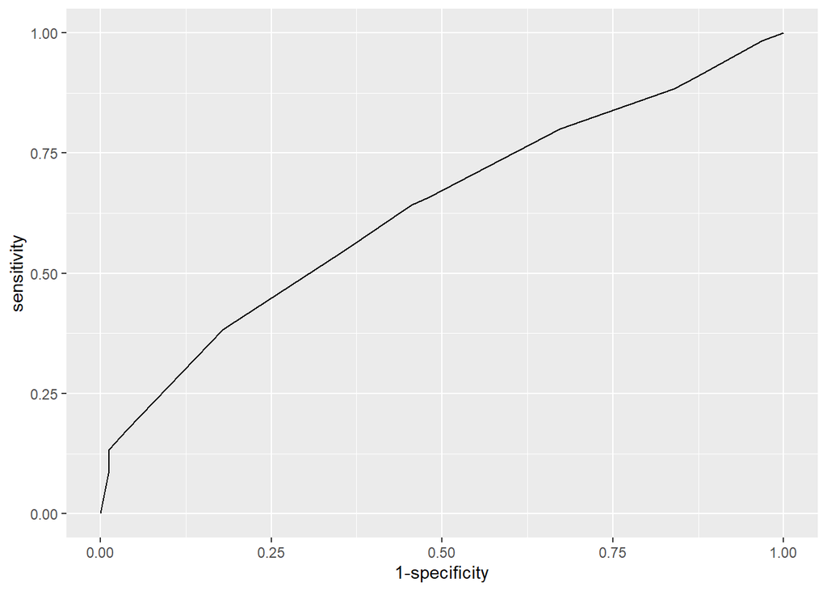

```r
res$auc
```

```
## Area under the curve: 0.6336
```

As the area under the curve is low (Not close to 1) and a model which is not closer to the upper and the right margin suggests that it is a bad model.

Thanks and regards Shreepati Jha